**Dynamical Systems:**  
**Forced Response**

Table of Contents

# 1. Linear Time-Invariant (LTI) Systems

The system $H$ represents a transformation (or rule) that maps an input signal $x(t)$ to an output signal $y(t)$:

$$ y(t) = H\{x(t)\}. $$

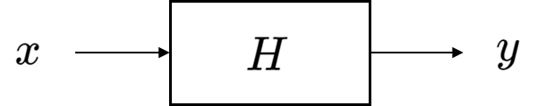

System Examples:

$$ \begin{aligned} \text{Identity:} &\quad y(t) = x(t) &\quad &\forall t \\ \text{Scaling:} &\quad y(t) = 2x(t) &\quad &\forall t \\ \text{Offset:} &\quad y(t) = x(t) + 2 &\quad &\forall t \\ \text{Square Signal:} &\quad y(t) = x(t)^2 &\quad &\forall t \\ \text{Shift:} &\quad y(t) = x(t+2) &\quad &\forall t \\ \text{Decimate:} &\quad y(t) = x(2t) &\quad &\forall t \\ \text{Square Time:} &\quad y(t) = x(t^2) &\quad &\forall t \end{aligned} $$

## 1.1. Linear Systems

A system $H$ is called **linear** if it satisfies:

(1) Scaling:

$$ H\{\alpha x(t)\} = \alpha H\{x(t)\}, \quad \forall \alpha \in \mathbb{C} $$

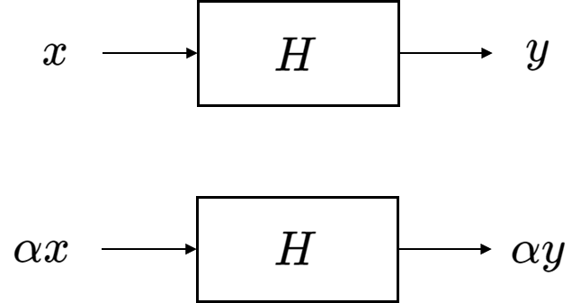

(2) Additivity:

If $y_1 = H{x_1}$ and $y_2 = H{x_2}$, then:

$$ H\{x_1 + x_2\} = y_1 + y_2. $$

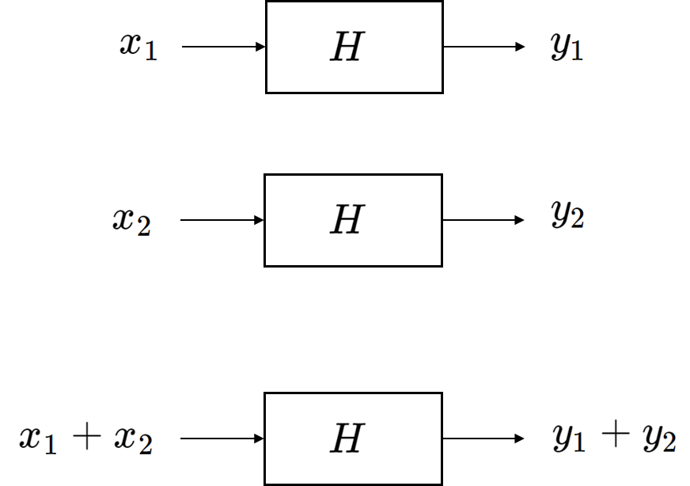

## 1.2. Time-Invariant Systems

A system $H$ is **time-invariant** if shifting the input signal causes an identical shift in the output:

$$ \text{If } y(t) = H\{x(t)\}, \quad \text{then } H\{x(t - \tau)\} = y(t - \tau), \quad \forall \tau. $$

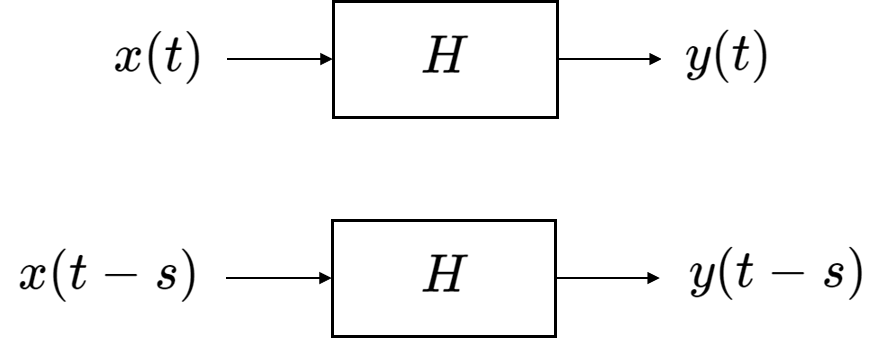

## 1.3. Linear Time-Invariant (LTI) Systems

We focus on systems that are both linear and time-invariant:

$$ H\{\alpha_1 x_1 + \alpha_2 x_2\}(t) = \alpha_1 H\{x_1\}(t) + \alpha_2 H\{x_2\}(t), $$

and:

$$ H\{x(t-\tau)\} = H\{x\}(t-\tau). $$

$$\begin{align*} \text{Identity} &\qquad y(t) = x(t) \quad &\forall t &\qquad \text{Linear} &\qquad \text{Time Invariant}\\ \text{Scaling} &\qquad y(t) = 2\,x(t) \quad &\forall t &\qquad \text{Linear} &\qquad \text{Time Invariant}\\ \text{Offset} &\qquad y(t) = x(t)\, + \,2 \quad &\forall t &\qquad \text{Non Linear} &\qquad \text{Time Invariant}\\ \text{Square signal} &\qquad y(t) = (x(t))^2 \quad &\forall t &\qquad \text{Non Linear} &\qquad \text{Time Invariant}\\ \text{Shift} &\qquad y(t) = x(t + 2) \quad &\forall t &\qquad \text{Linear} &\qquad \text{Time Invariant}\\ \text{Decimate} &\qquad y(t) = x(2t) \quad &\forall t &\qquad \text{Linear} &\qquad \text{Time Variant}\\ \text{Square time} &\qquad y(t) = x(t^2) \quad &\forall t &\qquad \text{Linear} &\qquad \text{Time Variant}\\ \end{align*}$$

# 2. Response to Non-Zero Input

So far, we have examined the **natural response** of systems with zero input and non-zero initial conditions:

$$ \begin{aligned} \dot{y} + \frac{1}{\tau}y &= 0 \\\\ \ddot{y} + 2\zeta\omega_n\dot{y} + \omega_n^2y &= 0 \end{aligned} $$

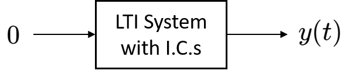

**Response to non-zero constant input**

Now, let’s analyze the response to non-zero constant input, which leads to inhomogeneous differential equations.

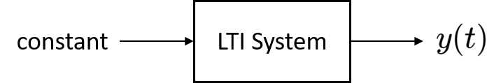

Assume the system is stable.

For constant forcing terms $q'$ or $p'$, the equations become:

$$ \begin{aligned} \dot{y} + \frac{1}{\tau}y &= q' \\\\ \ddot{y} + 2\zeta\omega_n\dot{y} + \omega_n^2y &= p' \end{aligned} $$

The system retains the same dynamics but converges to a different steady state.

Rewriting the equations by defining shifted variables:

$$ \begin{aligned} (\dot{y}-\dot{q}) + \frac{1}{\tau}(y-q) &= 0 \\\\ (\ddot{y}-\ddot{p}) + 2\zeta\omega_n(\dot{y}-\dot{p}) + \omega_n^2(y-p) &= 0 \end{aligned} $$

This shows that:

- **Transient response** appears immediately after system activation and decays if the system is stable.
- **Steady-state response** dominates in the long run, with all transients vanishing.

In steady state:

$$ \frac{dy}{dt} \to 0, \quad \frac{d^2y}{dt^2} \to 0 $$

**Example 1**: First-Order System

$$ \dot{y} + \frac{1}{\tau}y = q, \quad y(0) = 0 $$

At steady state:

$$ \dot{y}(\infty) = 0 \implies y(\infty) = \tau q $$

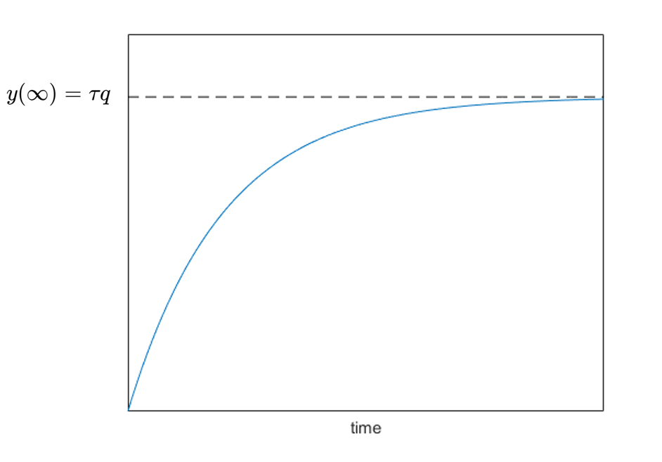

**Example 2**: Second-Order System

$$ \ddot{y} + 2\zeta\omega_n\dot{y} + \omega_n^2y = p, \quad y(0) = 0, \quad \dot{y}(0) = 0 $$

At steady state:

$$ \ddot{y}(\infty) = \dot{y}(\infty) = 0 \implies y(\infty) = \frac{p}{\omega_n^2} $$

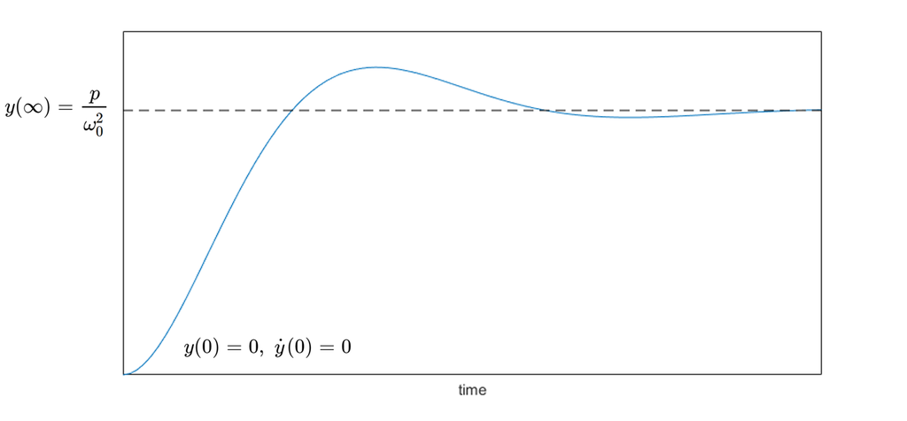

**Example 3**: Mass-Spring-Damper System

(1) Horizontal Setup:

$$ \ddot{y} + \frac{c}{m}\dot{y} + \frac{k}{m}y = 0, \quad y(0) = y_0, \quad \dot{y}(0) = 0 $$

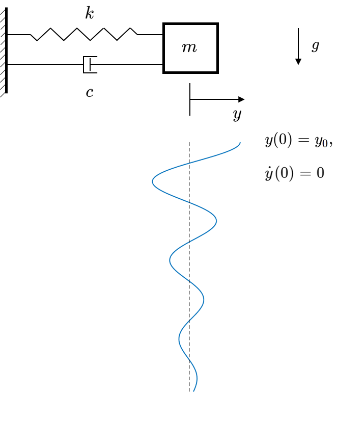

(2) Vertical Setup (subject to gravity):

- $y(0) = 0 \;$ no initial displacement
- $\dot{y}(0) = 0\;$ initially at rest

$$ \begin{aligned} m\ddot{y} + c\dot{y} + ky &= mg \\\\ \ddot{y} + \frac{c}{m}\dot{y} + \frac{k}{m}y &= g, \quad y(0) = 0, \quad \dot{y}(0) = 0 \end{aligned} $$

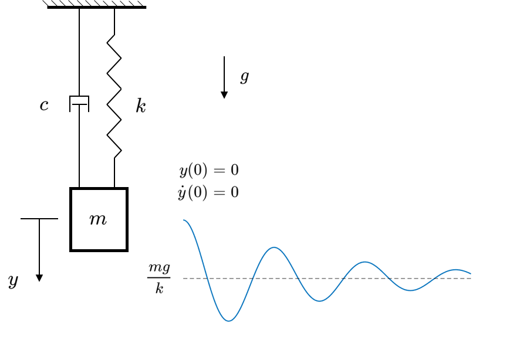

By shifting the origin to the static equilibrium point:

$$ y_{\text{eq}} = \frac{mg}{k} $$

the system behaves as a natural response starting from:

$$ y(0) = -\frac{mg}{k}, \quad \dot{y}(0) = 0 $$

General Interpretation:

$$ \ddot{y} + 2\zeta\omega_n\dot{y} + \omega_n^2y = \omega_n^2 p $$

Rewriting:

$$ (\ddot{y}-\ddot{p}) + 2\zeta\omega_n(\dot{y}-\dot{p}) + \omega_n^2(y-p) = 0 $$

This shows the system is a **shifted version** of the natural response around $p$.

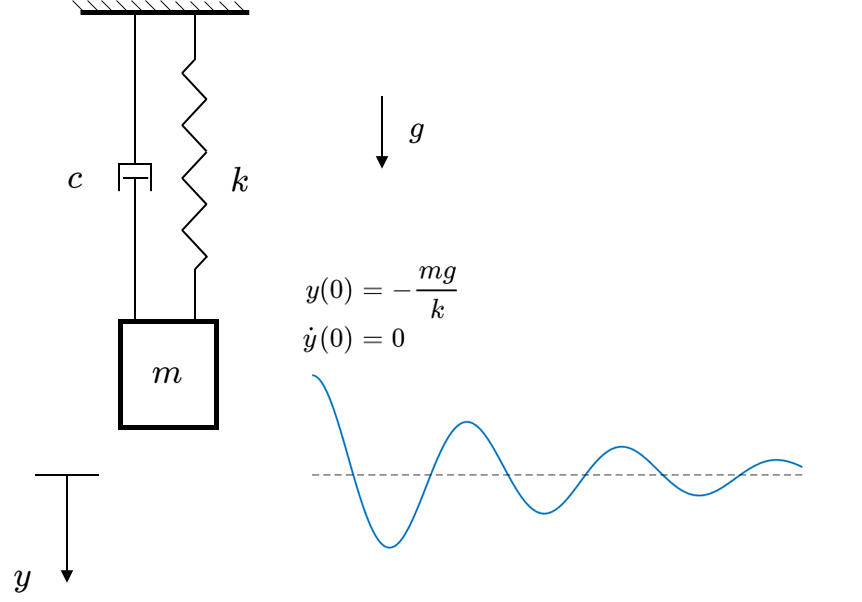

# 3. Time Response to General Inputs

Up to this point, we have examined system responses to constant inputs or initial conditions. Now we move to **general inputs** and how an **LTI system** behaves in these scenarios. The main tool we use is the **convolution integral**.

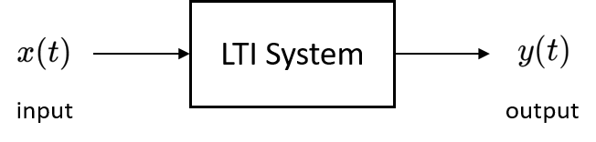

## 3.1. Step Response: Example and Interpretation

Consider a simple first-order system:

$$ \dot{x} + 5x = 1 \quad \text{for} \quad t \geq 0, \qquad x(0) = 0$$

$$ \dot{x} + 5x = u(t), \quad x(0)=0, $$

where $u(t)$ is the unit step function:

$$ u(t) = \begin{cases} 1, & t \geq 0, \\ 0, & t < 0. \end{cases} $$

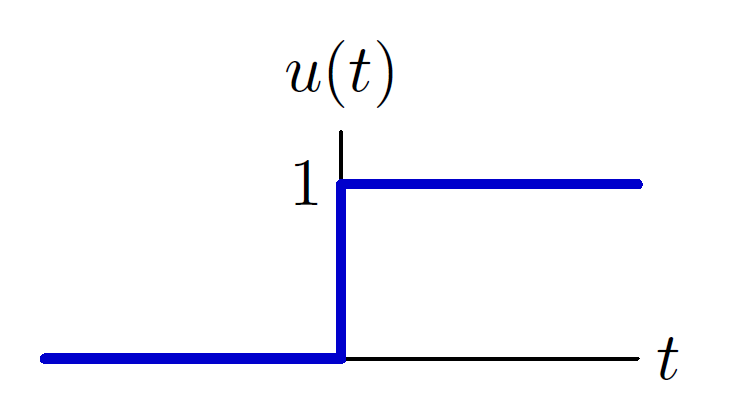

This models a system that is initially at rest, and at time $t=0$, a constant input of 1 is suddenly applied. The solution is:

$$ x(t) = \frac{1}{5}(1 - e^{-5t}). $$

- The system starts at zero and asymptotically approaches the steady-state value $x(\infty)=\frac{1}{5}$.
- The transient term $e^{-5t}$ decays exponentially with a time constant $\tau=1/5$.

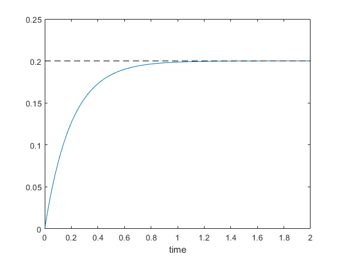

```matlab
t = linspace(0,2,100);
x = 1/5*(1-exp(-5*t));

plot(t,x,t,0.2*ones(size(t)),'k--')
ylim([0,0.25])
xlabel('time')
```

## 3.2. Impulse Response

**The Unit Impulse Signal: Dirac Delta Function**

The Dirac delta function $\delta(t)$ serves as a mathematical model of an idealized pulse—zero width, infinite height, and unit area. This is a conceptual construct used to model instantaneous impulses applied at a specific point in time, such as a sudden jolt of force or current.

Formal Definition

$$\delta(t) = \lim_{\epsilon\rightarrow0}p_\epsilon(t)$$

where $p_\epsilon(t)$ is a rectangular pulse of width $2\epsilon$ and height $\frac{1}{2\epsilon}$, having a unit area regardless of $\epsilon$:

$$ \int_{-\epsilon}^{\epsilon} p_\epsilon(t) \, dt = 1. $$

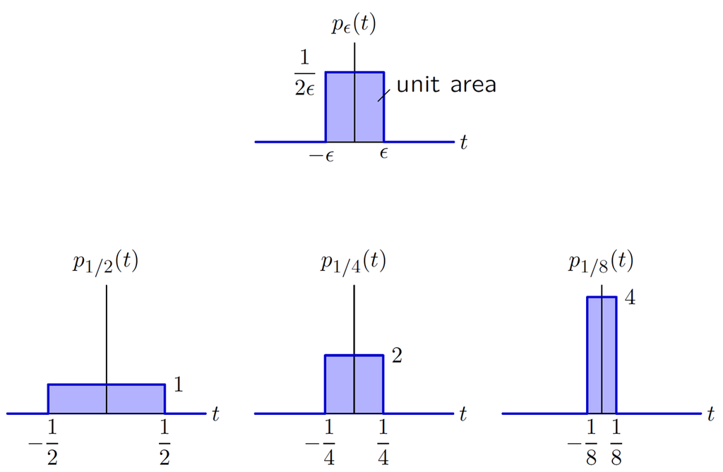

As $\epsilon \to 0$, the pulse becomes an infinitely thin spike at $t=0$ with unit area—this is $\delta(t)$.

The unit-impulse function is represented by an arrow with the number 1, which represents its area.

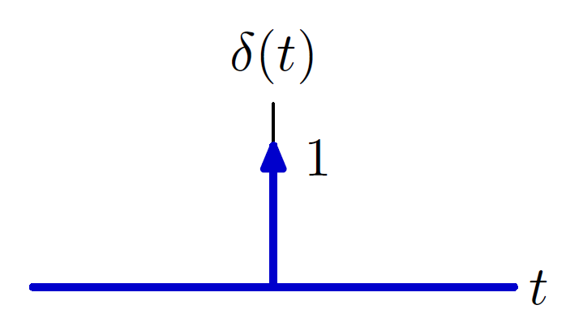

**Key Properties of $\delta(t)$**

(1) Zero everywhere except at $t=0$:

$$ \delta(t) = \begin{cases} \infty, & t=0, \\[8pt] 0, & t \ne 0. \end{cases} $$

(2) Unit area under the curve:

$$ \int_{-\infty}^{\infty} \delta(t) \, dt = 1. $$

(3) Sifting property: It "samples" functions at a point:

$$ \begin{align*} \int_{-\infty}^{\infty}x(t)\delta(t)dt &= \int_{-\infty}^{0^-}x(t)\delta(t)dt + \int_{0^-}^{0^+}x(t)\delta(t)dt + \int_{0^+}^{\infty}x(t)\delta(t)dt \\&= 0 + x(0)\int_{0^-}^{0^+}\delta(t)dt + 0 \\&= x(0) \end{align*}$$

or more generally:

$$ \int_{-\infty}^{\infty} x(\tau) \delta(t-\tau) \, d\tau = x(t). $$

### 3.2.1. Impulse and Initial Velocity in Mass-Spring-Damper Systems

**1. Question: How to Realize an Initial Velocity $v_0 \ne 0$?**

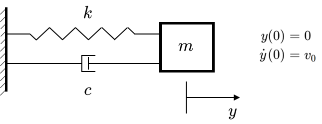

The key idea comes from Newton's Second Law and the concept of impulse:

- Impulse is the integral of force over time:

$$ \Delta p = \int_{0^-}^{0^+} F(t) dt = m v_0 - m(0) = m v_0. $$

- A delta function force $F(t) = m v_0 \delta(t)$ applied at $t=0$ instantaneously changes the momentum of the mass:

$$ F(t) = m v_0 \delta(t), $$

$\quad$ which results in:

$$ \dot{y}(0^+) = v_0, \quad y(0) = 0. $$

This models an instantaneous "kick" to the mass.

**2. Mathematical Model**

For a mass-spring-damper system:

$$ m\ddot{y} + c\dot{y} + k y = F(t). $$

With an impulse force:

$$ F(t) = m v_0 \delta(t), $$

this becomes:

$$ m\ddot{y} + c\dot{y} + k y = m v_0 \delta(t), $$

or after dividing by $m$:

$$ \ddot{y} + \frac{c}{m}\dot{y} + \frac{k}{m}y = v_0 \delta(t). $$

The **impulse** at $t=0$ injects momentum:

$$ \Delta p = m v_0. $$

This results in:

$$ v_0 \delta(t) \quad \longrightarrow \quad \begin{cases} y(0) = 0,\\[10pt] \dot{y}(0) = v_0, \end{cases} \quad \longrightarrow \quad \text{natural response}. $$

**Interpretation**:

After the impulse (a “kick”), the system behaves as if it started from rest at $y=0$ but with an initial velocity $\dot{y}(0)=v_0$. This **natural response** evolves based on the system's inherent dynamics.

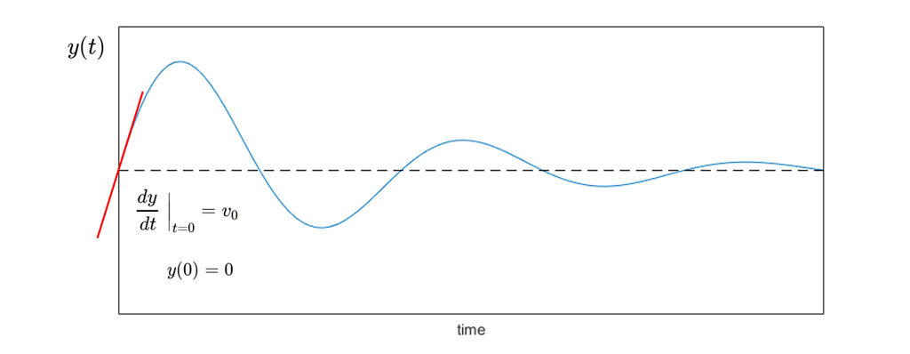

### 3.2.2. Impulse Response to LTI System

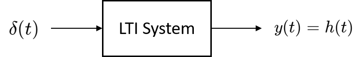

The impulse response is a fundamental concept for analyzing Linear Time-Invariant (LTI) systems. It characterizes how a system reacts to a very short input of unit area, namely the Dirac delta function $\delta(t)$.

Consider the second-order system:

$$ \ddot{y} + 2\zeta \omega_n \dot{y} + \omega_n^2 y = \delta(t) $$

where:

$$ \delta(t): \text{input}, \quad y(t): \text{output} $$

The response $y(t)$ to $\delta(t)$ fully characterizes the system's behavior. The impulse response $h(t)$ can later be used to compute the response to any input $x(t)$ via convolution:

$$ y(t) = h(t) * x(t) = \int_{-\infty}^{\infty} h(\tau) x(t-\tau) d\tau $$

**Example**:

Impulse Response of a First-Order System

$$ \dot{y} + 5y = \delta(t), \quad y(0) = 0 $$

The solution to this equation is:

$$ y(t) = h(t) = e^{-5t}, \quad t \ge 0 $$

Why is this the solution?

- Interpretation: The system experiences an impulse $\delta(t)$ at $t=0$, causing an instantaneous change in $y$.
- Impulse integral:

$$ \int_{0^-}^{0^+} \delta(t) dt = u(0^+) - u(0^-) = 1 $$

which can be interpreted as an instantaneous jump of 1 in the output.

After the impulse at $t=0$, the system evolves according to its homogeneous equation:

$$ \dot{y} + 5y = 0, \quad y(0) = 1 $$

leading to the natural response:

$$ y(t) = e^{-5t} $$

Key Insight

- The impulse response is the system's fingerprint.
- It reveals how the system reacts to the simplest possible input.
- It forms the foundation for determining the system's output to any input via convolution.

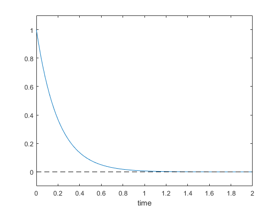

```matlab
t = linspace(0,2,100);
h = exp(-5*t);

plot(t,h,t,zeros(size(t)), 'k--'),
ylim([-0.1,1.1])
xlabel('time')
```

## 3.3. Step Response

Consider the system:

$$ \begin{align*} \ddot{x} + 2\zeta\omega_n\dot{x}+\omega^2_nx &= u(t) &\text{or} \\ \\ \ddot{x} + 2\zeta\omega_n\dot{x}+\omega^2_nx &= 1, &t > 0 \end{align*} $$

The solution has two components:

- Transient response, determined by natural modes (eigenvalues of the system).
- Steady-state response, driven by the input $u(t)$.

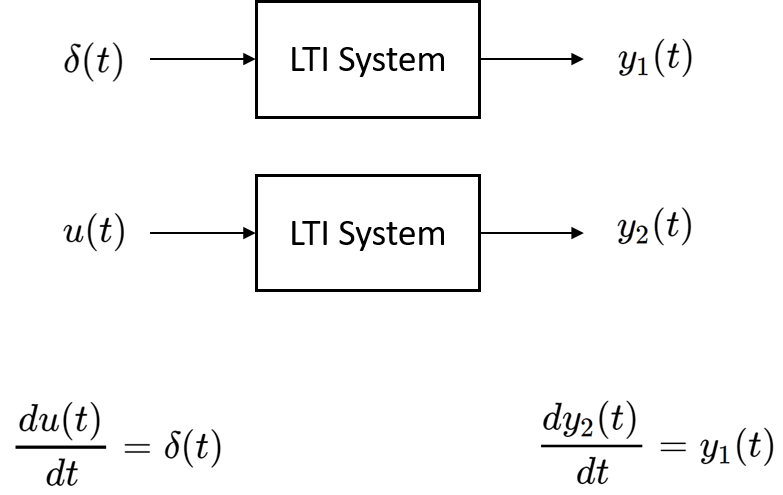

Key point: The derivative of the step response $y_2(t)$ gives the impulse response $y_1(t)$.

## 3.4. Response to a General Input (in Time)

So far, we've analyzed systems with constant or simple inputs (such as step and impulse). But real-world systems often encounter more complex inputs $x(t)$. How can we determine the system’s response $y(t)$ for any input?

**Setup:**

Consider the first-order linear differential equation:

$$ \dot{y} + 5 y = x(t), \quad y(0) = 0 $$

This represents an LTI system (linear, time-invariant).

**Key Idea:**

The solution can be expressed using the system's impulse response $h(t)$:

$$ y(t) = h(t) * x(t) $$

where the symbol $*$ denotes convolution.

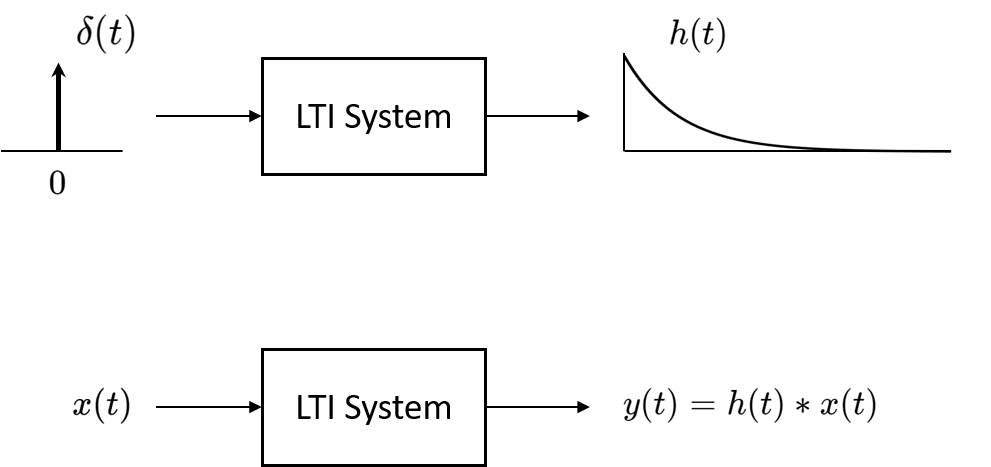

If this is true, we can compute output response to any general input if an impulse response is given

**Convolution Definition:**

For continuous-time signals:

$$ \begin{align*} y(t) = (h * x)(t) &= \int_{-\infty}^{\infty} h(\tau) x(t - \tau) d\tau \\ &= \int_{-\infty}^{\infty} x(\tau) h(t - \tau) d\tau \end{align*} $$

**Why This Works:**

Time-Invariance and Linearity

(1) Time-invariance ensures that if an impulse input $\delta(t-\tau)$ is shifted by $\tau$, the system's response is simply a shifted impulse response $h(t-\tau)$.

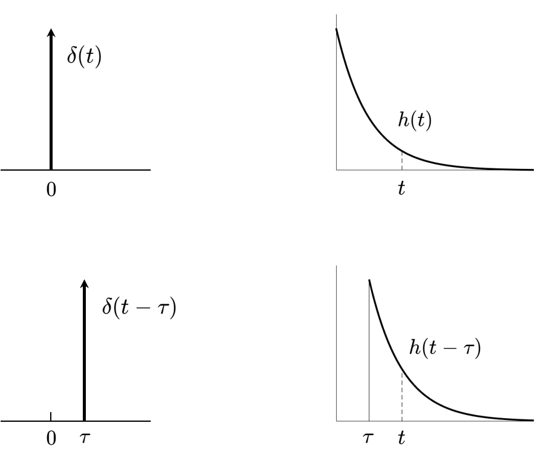

(2) Linearity implies that the response to a scaled impulse input $x(\tau) \delta(t-\tau)$ is $x(\tau) h(t-\tau)$—that is, the impulse response is scaled by the amplitude $x(\tau)$.

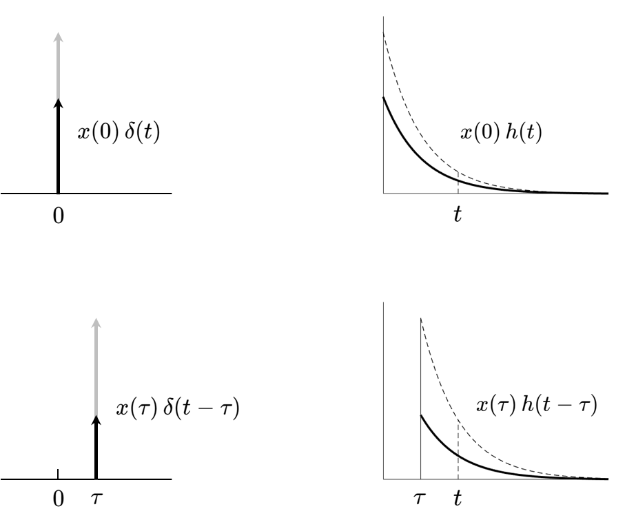

**Response to Arbitrary Input $x(t)$**

The impulse response $h(t)$ characterizes how the system reacts to the simplest possible input: the Dirac delta function $\delta(t)$, which represents a "spike" at a single point in time.

A general input signal $x(t)$ can be decomposed into an infinite sum (or integral) of weighted, shifted impulses:

$$ \begin{align*} x(t) &= \int_{-\infty}^{\infty} x(\tau) \, \delta(t-\tau) \, d\tau \end{align*} $$

Each $\delta(t-\tau)$ in this decomposition contributes a response $h(t-\tau)$.

By superposition (linearity), the system output $y(t)$ is the sum (integral) of these scaled and shifted responses:

$$y(t) = \int_{-\infty}^{\infty} x(\tau) \, h(t-\tau) \, d\tau \; = \; x(t) * h(t)$$

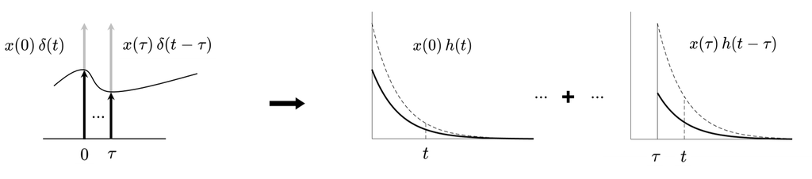

Thus, convolution with $h(t)$ completely characterizes the system’s behavior for any input $x(t)$.

**Example:**

Let's consider:

$$ \dot{y} + 3 y = 3 x(t) $$

with impulse response:

$$ h(t) = 3e^{-3t}, \quad t \ge 0 $$

If $x(t)$ is a general input (e.g., square wave, ramp, sine wave), we can compute $y(t)$ by:

$$ y(t) = h(t)*x(t) = \int_{0}^{t} 3e^{-3(t-\tau)} x(\tau) d\tau $$

This integral sums the weighted past values of $x(\tau)$, with the weighting determined by how much time has passed (via $3e^{-3(t-\tau)}$).

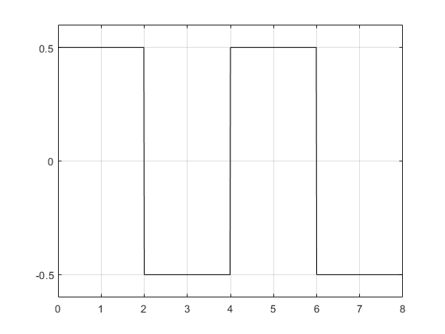

```matlab
% generate a general input

T = 4;

fs = 100;
Ts = 1/fs;
t = 0:Ts:2*T-Ts;

w0 = 2*pi/T;
x = 1/2*square(w0*t);

plot(t,x,'k')
grid on
ylim([-0.6,0.6])
yticks([-0.5,0,0.5])
```

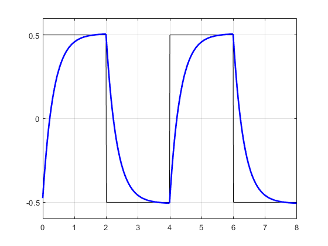

```matlab
% convolution (circular, will be discussed later)

h = 3*exp(-3*t);
y = cconv(x,h,length(t))*Ts;

plot(t,x,'k'), hold on
plot(t,y,'b', 'linewidth',2), hold off
grid on
ylim([-0.6,0.6])
yticks([-0.5,0,0.5])
```

# 4. Frequency Response to General Input (in Frequency)

## 4.1. Response to a Sinusoidal Input

A remarkable property of LTI (Linear Time-Invariant) systems is that when the input is a complex exponential of the form

$$ x(t) = e^{j\omega t} $$

the output is the same exponential multiplied by a complex number that depends only on $\omega$:

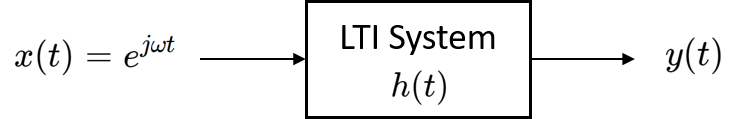

Let the system's impulse response be $h(t)$. The output is given by convolution:

$$ y(t) = h(t) * x(t) = \int_{-\infty}^{\infty} h(\tau) \, x(t - \tau) \, d\tau $$

Substituting $x(t) = e^{j\omega t}$:

$$ \begin{align*} y(t) &= \int_{-\infty}^{\infty} h(\tau) \, e^{j\omega(t - \tau)} \, d\tau \\\\ &= e^{j\omega t} \underbrace{\int^\infty_{-\infty}h(\tau)e^{-j\omega \tau}d\tau}_{\text{complex function of } \omega} \\\\ &= e^{j\omega t} \cdot H(j\omega) \end{align*} $$

where

$$ H(j\omega) = \int_{-\infty}^{\infty} h(t) e^{-j\omega t} dt $$

is the Fourier Transform of the impulse response $h(t)$.

Definition: **Fourier Transform**

$$H(j\omega) = \int^\infty_{-\infty}h(\tau)e^{-j\omega \tau}d\tau$$

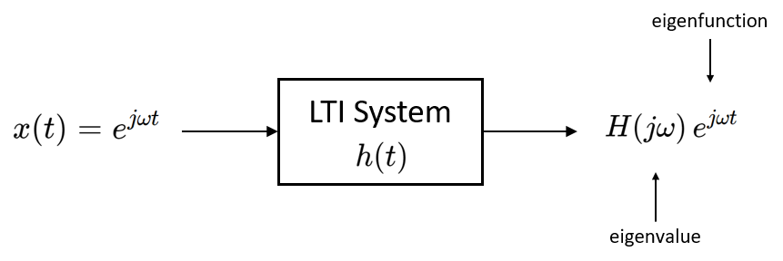

**Interpretation**

- The system does not change the frequency of the input.
- The output is a scaled and phase-shifted version of the input.

That is,

$$ y(t) = \lvert H(j\omega) \rvert \cdot e^{j\omega t + j \angle H(j\omega)} $$

Here:

- $\lvert H(j\omega) \rvert$ is the gain (amplitude response)
- $\angle H(j\omega)$ is the phase shift introduced by the system

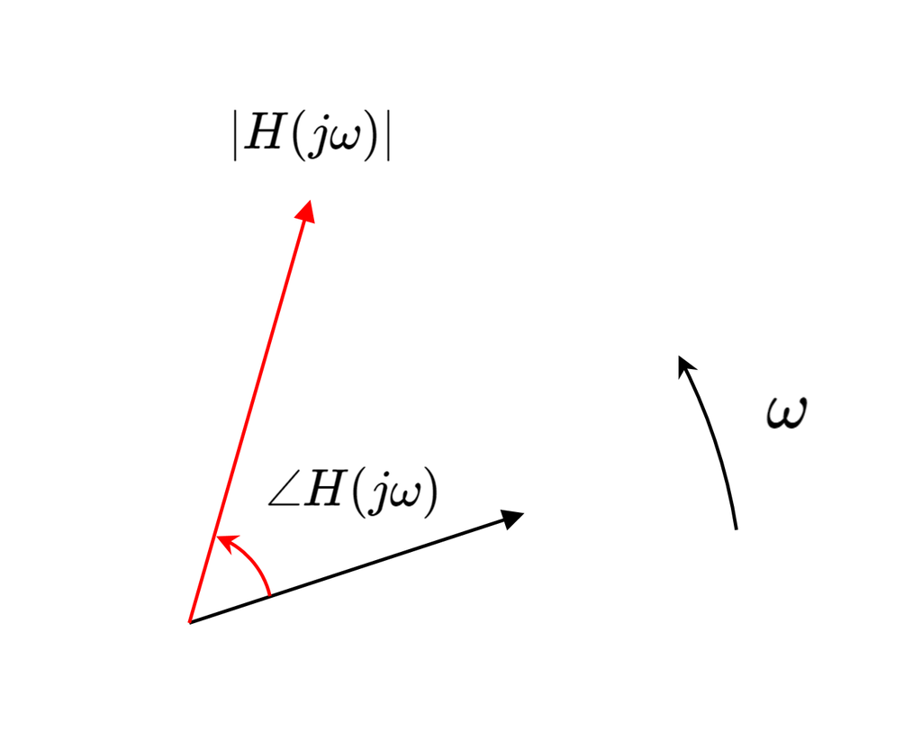

$y(t) = H(j\omega)e^{j\omega t}$ rotates with the same angular velocity $\omega$

$$ \begin{align*} y(t) &= H(j\omega) e^{j\omega t}\\ (j\omega) &= \lvert H(j\omega) \rvert e^{j\angle H(j\omega)} \end{align*} $$

**Example**: Frequency Response of

$$ \dot{y} + 5y = x(t)$$

This is a linear time-invariant (LTI) system. We want to understand how it responds to sinusoidal input using the frequency domain.

We express $H(j\omega)$ in polar form:

$$ \lvert H(j\omega) \rvert = \frac{1}{\sqrt{25 + \omega^2}}, \qquad \angle H(j\omega) = -\tan^{-1}\left( \frac{\omega}{5} \right) $$

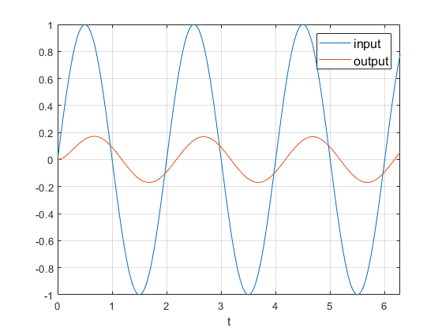

```matlab
% use lsim

A = -5;
B = 1;
C = 1;
D = 0;
G = ss(A,B,C,D);

w = pi;
t = linspace(0,2*pi,200);

x0 = 0;

x = sin(w*t);

[y,tout] = lsim(G,x,t,x0);

plot(t,x), hold on
plot(tout,y), hold off
grid on
xlabel('t')
axis tight, ylim([-1,1])
leg = legend('input','output');
set(leg, 'fontsize', 12)
```

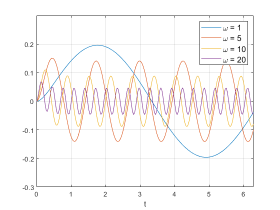

```matlab
% sinusoidal inputs with different w

A = -5;
B = 1;
C = 1;
D = 0;
G = ss(A,B,C,D);

x0 = 0;

t = linspace(0,2*pi,200);

W = [1,5,10,20];
for w = W
    x = sin(w*t);
    [y,tout] = lsim(G,x,t,x0);
    plot(tout,y), hold on
end

hold off
grid on
axis tight, ylim([-0.3,0.3])
xlabel('t')
leg = legend('\omega = 1','\omega = 5','\omega = 10','\omega = 20');
set(leg, 'fontsize', 12)
```